# Predictive Analytics-Final Assignment

Baivab Basnet, Shaurave Kumar Kunwar, Gaurav Nepal, Hemanta Adhikari

5/31/2020

# Predictive Analytics-Final Assignment

## Import the data and the libraries

First of all we import the necessart libraries needed for analysis and the dataset.

```r
library(dplyr)
```

```r
library(psych)
library(ggplot2)
library(ggpubr)
library(RColorBrewer)
data = read.csv("fish.csv", header = TRUE)
```

## Global Data Analysis and Data Structuring

The structure of the dataset is analysed using str() function.

```r
str(data)
```

```
## 'data.frame':    159 obs. of  7 variables:
##  $ ï..Species: chr  "Bream" "Bream" "Bream" "Bream" ...
##  $ Weight    : num  242 290 340 363 430 450 500 390 450 500 ...
##  $ Length1   : num  23.2 24 23.9 26.3 26.5 26.8 26.8 27.6 27.6 28.5 ...
##  $ Length2   : num  25.4 26.3 26.5 29 29 29.7 29.7 30 30 30.7 ...
##  $ Length3   : num  30 31.2 31.1 33.5 34 34.7 34.5 35 35.1 36.2 ...
##  $ Height    : num  11.5 12.5 12.4 12.7 12.4 ...
##  $ Width     : num  4.02 4.31 4.7 4.46 5.13 ...
```

Analysing the str of the dataset, we can see that “Species” is the only categorical variable, while the other 6 are continuous. Now we rename the cloumns for better understanding.

```r
names(data)<- c("Species", "Weight","Length1", "Length2","Length3", "Height", "Width")
```

Let us summarize the dataset using summary() function.

```r
summary(data)
```

```
##    Species              Weight          Length1         Length2
##  Length:159         Min.   :   0.0   Min.   : 7.50   Min.   : 8.40
##  Class :character   1st Qu.: 120.0   1st Qu.:19.05   1st Qu.:21.00
##  Mode  :character   Median : 273.0   Median :25.20   Median :27.30
##                     Mean   : 398.3   Mean   :26.25   Mean   :28.42
##                     3rd Qu.: 650.0   3rd Qu.:32.70   3rd Qu.:35.50
##                     Max.   :1650.0   Max.   :59.00   Max.   :63.40
##     Length3          Height           Width
##  Min.   : 8.80   Min.   : 1.728   Min.   :1.048
##  1st Qu.:23.15   1st Qu.: 5.945   1st Qu.:3.386
##  Median :29.40   Median : 7.786   Median :4.248
##  Mean   :31.23   Mean   : 8.971   Mean   :4.417
##  3rd Qu.:39.65   3rd Qu.:12.366   3rd Qu.:5.585
##  Max.   :68.00   Max.   :18.957   Max.   :8.142
```

Check if there are any missing values in the dataset

```r
miss<-sum(is.na(data))
print(paste("Number of  missing values:-",miss))
```

```
## [1] "Number of  missing values:- 0"
```

The answer is zero, so there are no missing values in our dataset.

We again filter the values 0 from the dataset

```r
fish<- data%>% filter(Weight>0,Length1>0,Length2>0,Length3>0,Height>0,Width>0)
fish$Species<-as.factor(fish$Species)
```

Now we have a clean dataset with no NAN and 0 values.

## Exploratory Analysis

The variable to be predicted(Dependent Variable) is Weight The independent variables(Predictors) are Length1,Length2, Length3, Height, Width and Species.

Distribution of the dependent variable Weight:

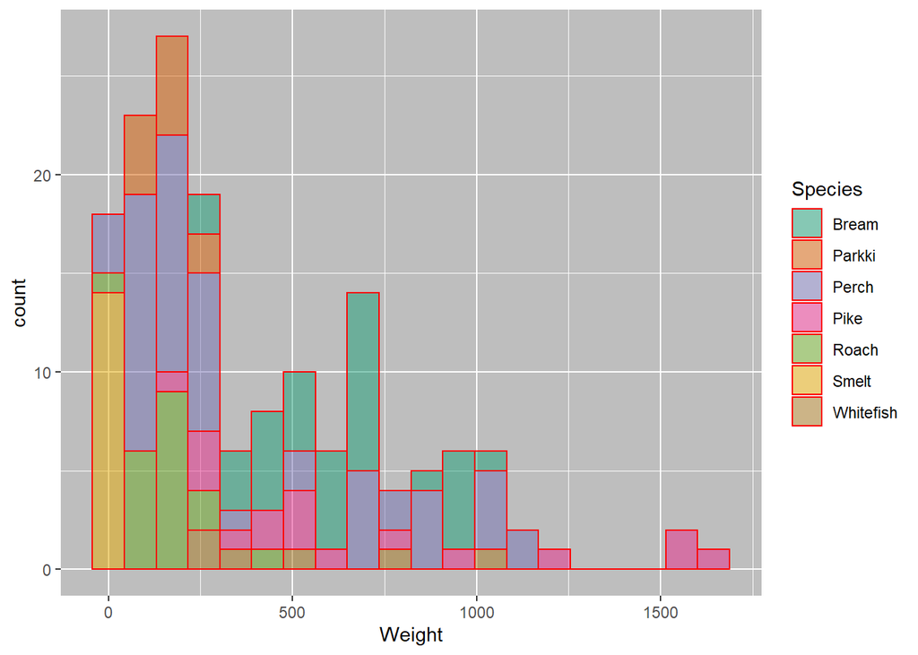

```r
ggplot(fish,aes(x=Weight,fill=Species))+
  geom_histogram(alpha=0.5,col="red",bins=20)+scale_color_brewer(palette = "Dark2")+scale_fill_brewer(palette = "Dark2")+
  theme(panel.background = element_rect(fill="grey"))
```

Looking at the histogram, we can see that there are some outliers for the species PIKE.

Diving further into data exploration We now check each independent and dependent variable according to the species.

```r
bp1<-ggplot(fish,aes(x=Species,y=Length1))+geom_boxplot()
bp2<-ggplot(fish,aes(x=Species,y=Length2))+geom_boxplot()
bp3<-ggplot(fish,aes(x=Species,y=Length3))+geom_boxplot()
bp4<-ggplot(fish,aes(x=Species,y=Height))+geom_boxplot()
bp5<-ggplot(fish,aes(x=Species,y=Width))+geom_boxplot()
bp6<-ggplot(fish,aes(x=Species,y=Weight))+geom_boxplot()
```

Using ggarange function to visualize all boxplots in one window

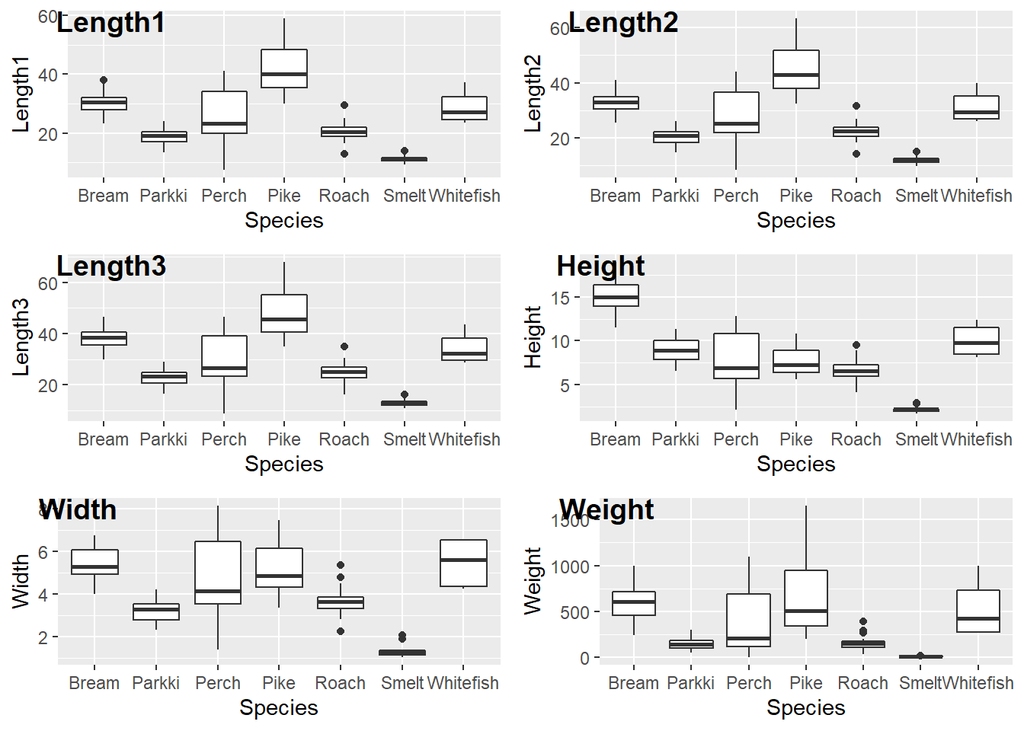

```r
ggarrange(bp1,bp2,bp3,bp4,bp5,bp6,labels=c("Length1","Length2","Length3","Height","Width","Weight"),ncol=2,nrow = 3)
```

we can observe that the data is not normally distributed. Another important point is that each species has different mean “WEIGHT”.

Now we use density plot to visualize further the distribution of weight by species. The vertical lines represent the mean of the weight of each species. As the original values of “WEIGHT” are highly variable, the density graph could not be properly visualized. Thus, we have used the log of WEIGHT, in order to visualize the data through density graph

First we calculate the means of each fish species.

```r
fish.means <- fish %>%
  group_by(Species)%>%
  summarise(Mean_weight=mean(log(Weight)))
```

Now we use density plot to visualize the data

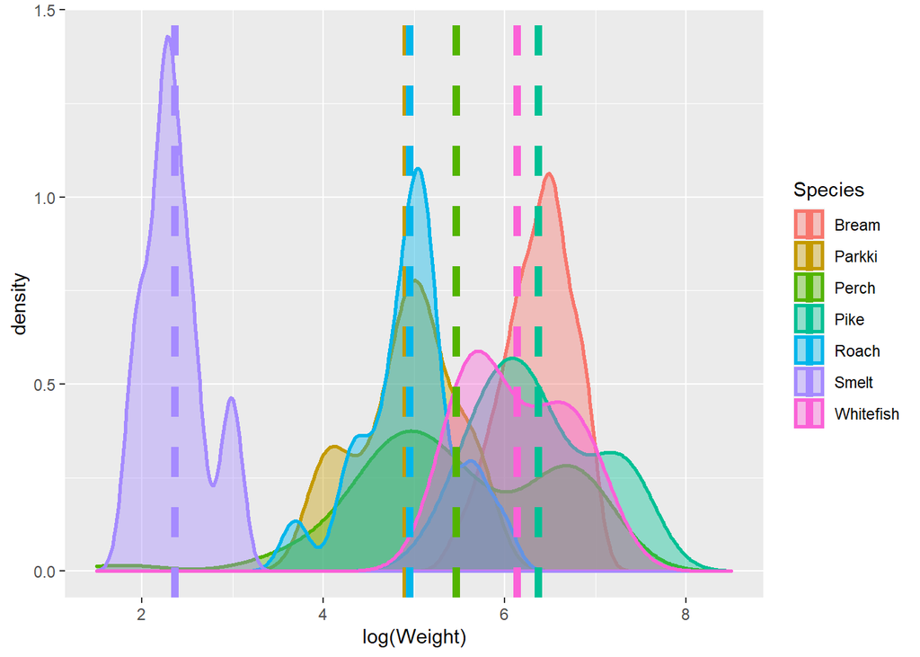

```r
ggplot(fish,aes(x=log(Weight),fill=Species,color=Species,group=Species))+
  geom_density(alpha=0.4,lwd=1)+
  geom_vline(data=fish.means,aes(xintercept = Mean_weight,color=Species),lwd=2,lty="dashed")+
  scale_x_continuous(limits = c(1.5,8.5))
```

The graph shows the different species-wise density and distribution of our dependent variable WEIGHT. It further supports our claim that the variables are not normally distributed.

Checking global relationship between our depenent variable(Weight) and other independent variables

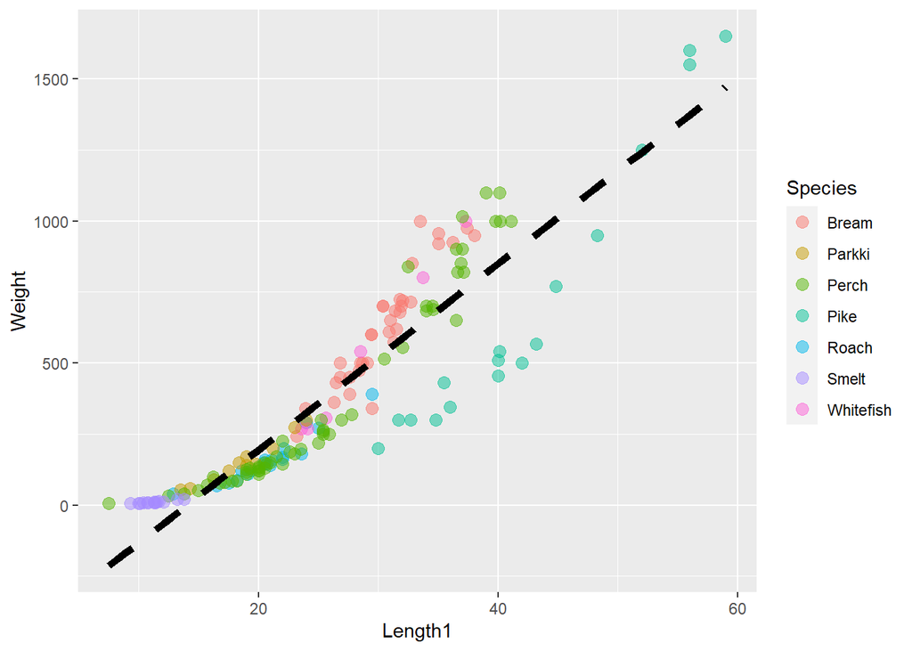

```r
l1<-ggplot( data = fish,mapping = aes(x = Length1, y = Weight,col=Species)) +geom_point(size=3,alpha=0.5) +geom_smooth(col="black",method = "lm",se=F,lty="dashed",lwd=2,formula="y~x")
l2<-ggplot( data = fish,mapping = aes(x = Length2, y = Weight,col=Species)) +geom_point(size=3,alpha=0.5) +geom_smooth(col="black",method = "lm",se=F,lty="dashed",lwd=2,formula="y~x")
l3<-ggplot( data = fish,mapping = aes(x = Length3, y = Weight,col=Species)) +geom_point(size=3,alpha=0.5) +geom_smooth(col="black",method = "lm",se=F,lty="dashed",lwd=2,formula="y~x")
h<-ggplot( data = fish,mapping = aes(x = Height, y = Weight,col=Species)) +geom_point(size=3,alpha=0.5) +geom_smooth(col="black",method = "lm",se=F,lty="dashed",lwd=2,formula="y~x")

w<-ggplot( data = fish,mapping = aes(x = Width, y = Weight,col=Species)) +geom_point(size=3,alpha=0.5) +geom_smooth(col="black",method = "lm",se=F,lty="dashed",lwd=2,formula="y~x")

l1
```

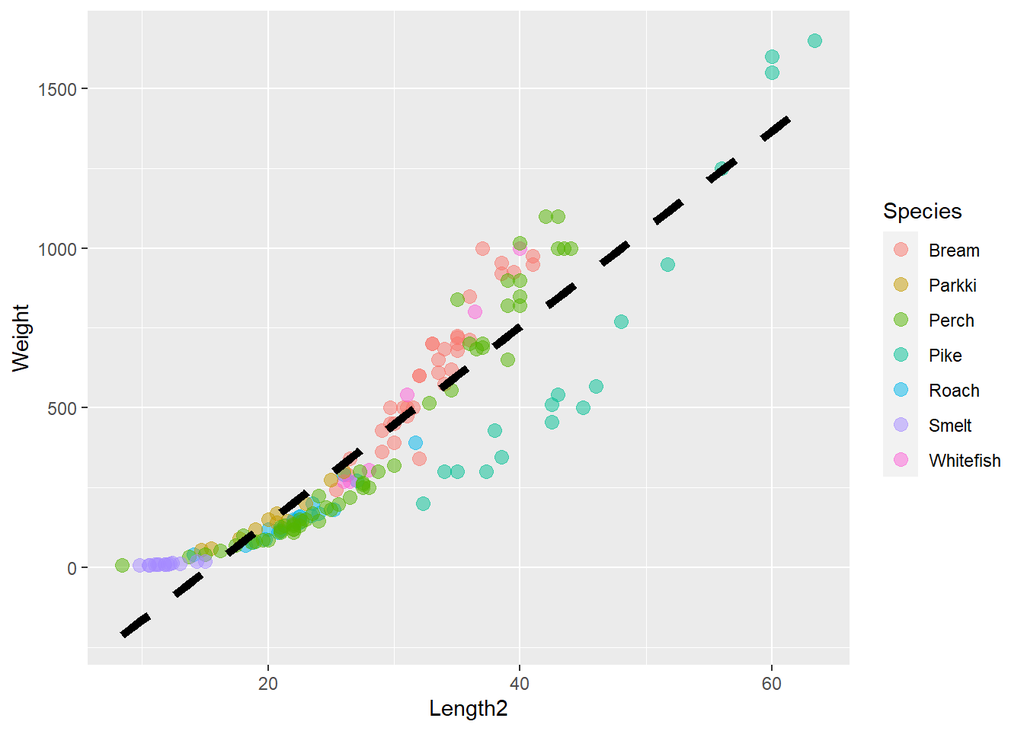

```r
l2
```

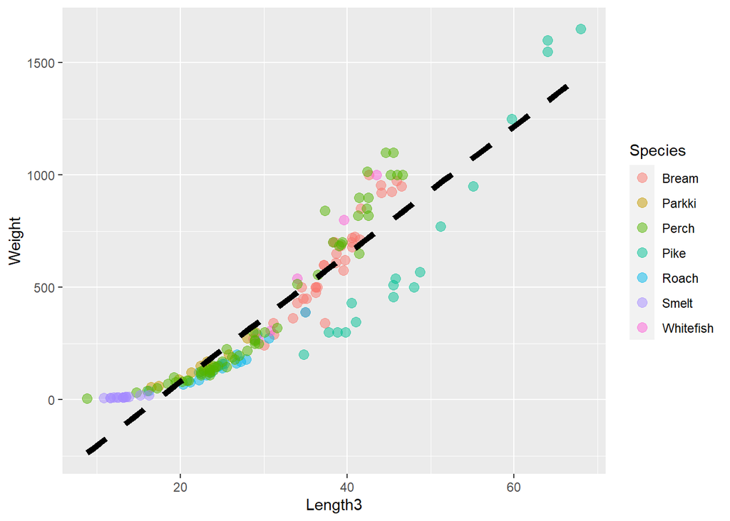

```r
l3
```

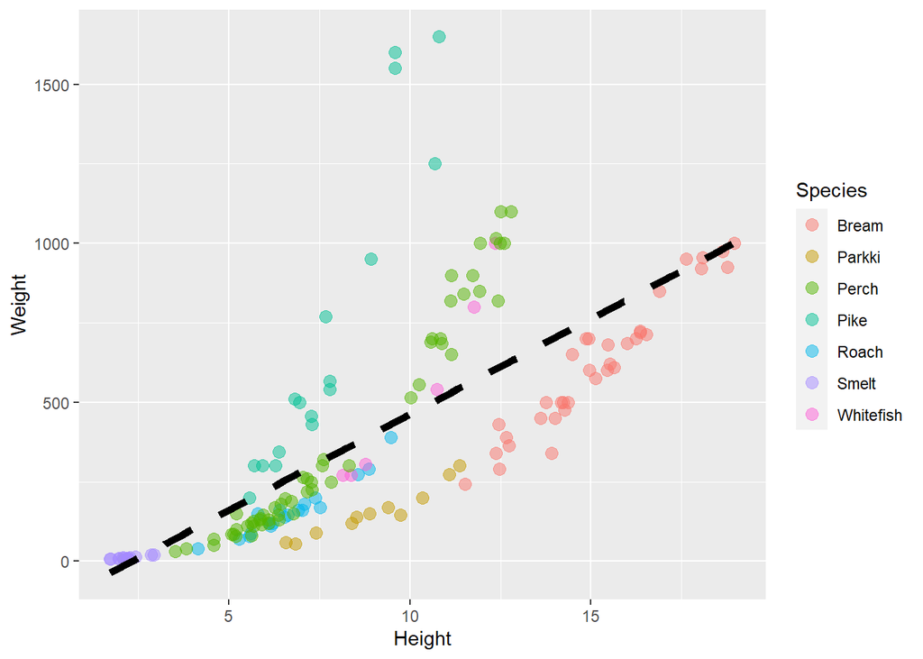

```r
h
```

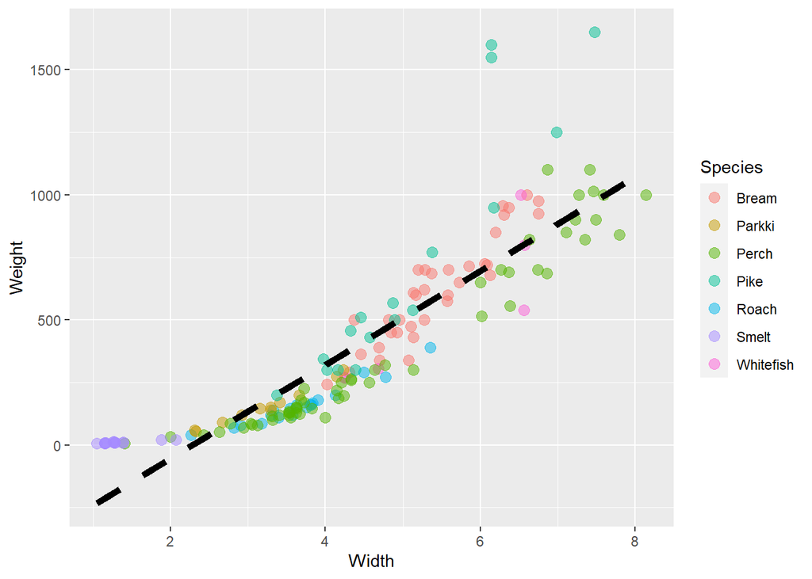

```r
w
```

So, we have two choices:-either we can use a non-linear model or we can use transformations to linearize the data.

As we are using linear regression on this model, We can use log transformations on the dataset and use the obtained dataset in our regression analysis.

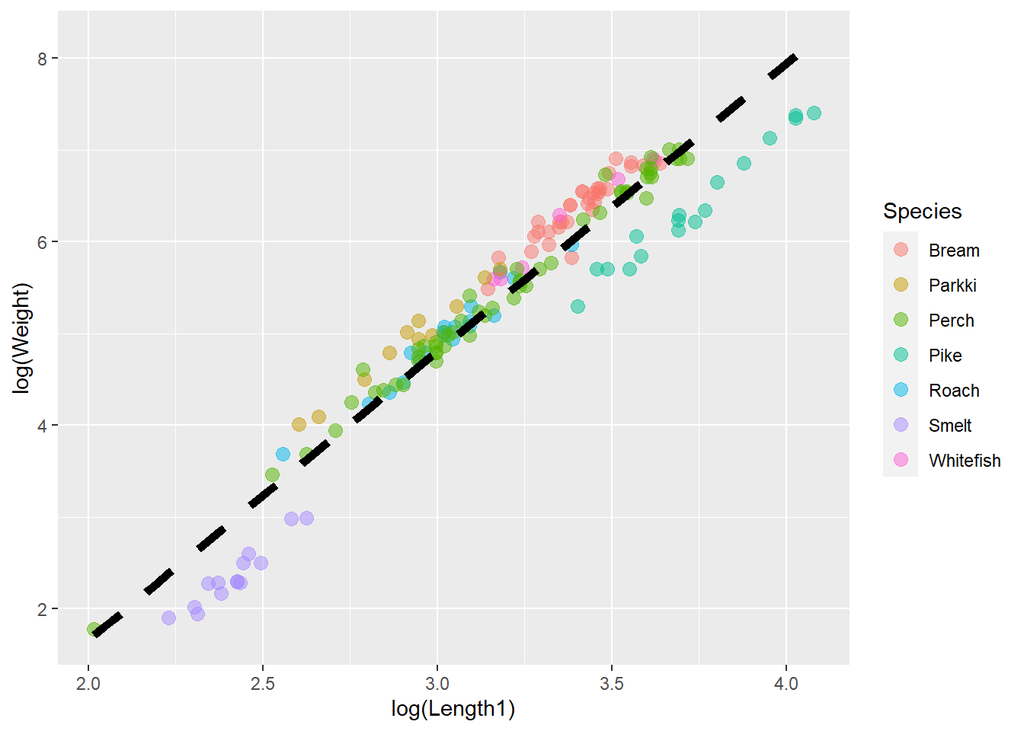

```r
l1_log<-ggplot( data = fish,mapping = aes(x = log(Length1), y =log(Weight),col=Species)) +geom_point(size=3,alpha=0.5) +geom_smooth(col="black",method = "lm",se=F,lty="dashed",lwd=2,formula="y~x")
l2_log<-ggplot( data = fish,mapping = aes(x = log(Length2), y = log(Weight),col=Species)) +geom_point(size=3,alpha=0.5) +geom_smooth(col="black",method = "lm",se=F,lty="dashed",lwd=2,formula="y~x")
l3_log<-ggplot( data = fish,mapping = aes(x = log(Length3), y = log(Weight),col=Species)) +geom_point(size=3,alpha=0.5) +geom_smooth(col="black",method = "lm",se=F,lty="dashed",lwd=2,formula="y~x")
h_log<-ggplot( data = fish,mapping = aes(x = log(Height), y = log(Weight),col=Species)) +geom_point(size=3,alpha=0.5) +geom_smooth(col="black",method = "lm",se=F,lty="dashed",lwd=2,formula="y~x")

w_log<-ggplot( data = fish,mapping = aes(x = log(Width), y = log(Weight),col=Species)) +geom_point(size=3,alpha=0.5) +geom_smooth(col="black",method = "lm",se=F,lty="dashed",lwd=2,formula="y~x")
l1_log
```

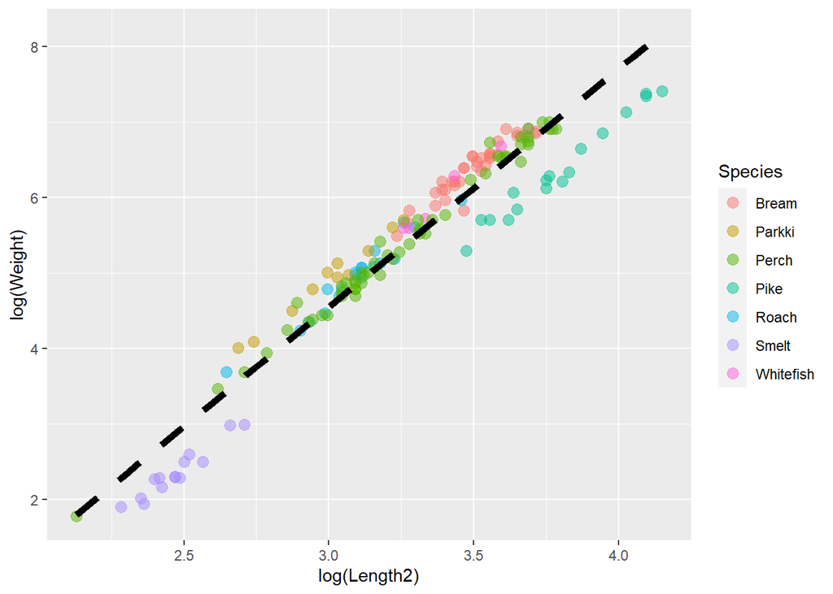

```r
l2_log
```

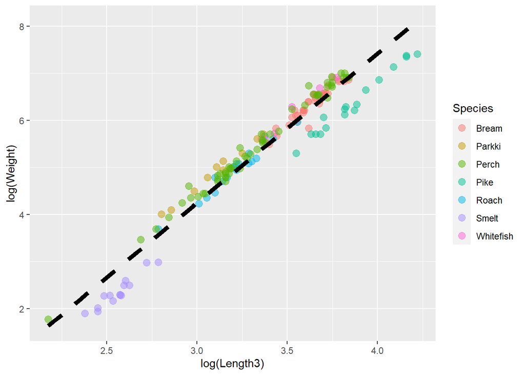

```r
l3_log
```

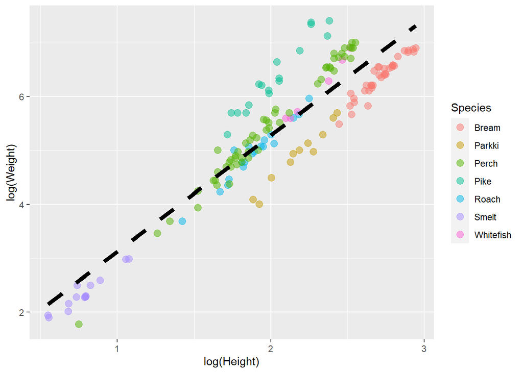

```r
h_log
```

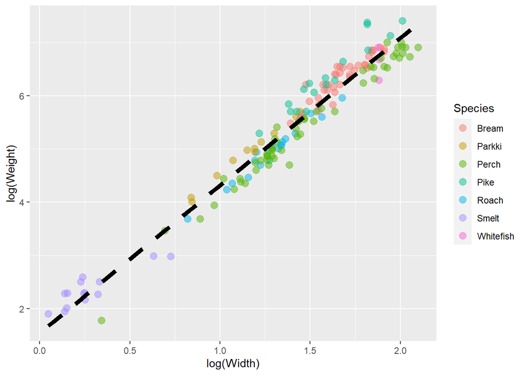

```r
w_log
```

We can observe that now, the relationships between “HEIGHT”and “WIDTH” with “WEIGHT” is linear. Now we can use linear regression to analyse and predict the data

We first check correlations between the dependent variable and independent variables.

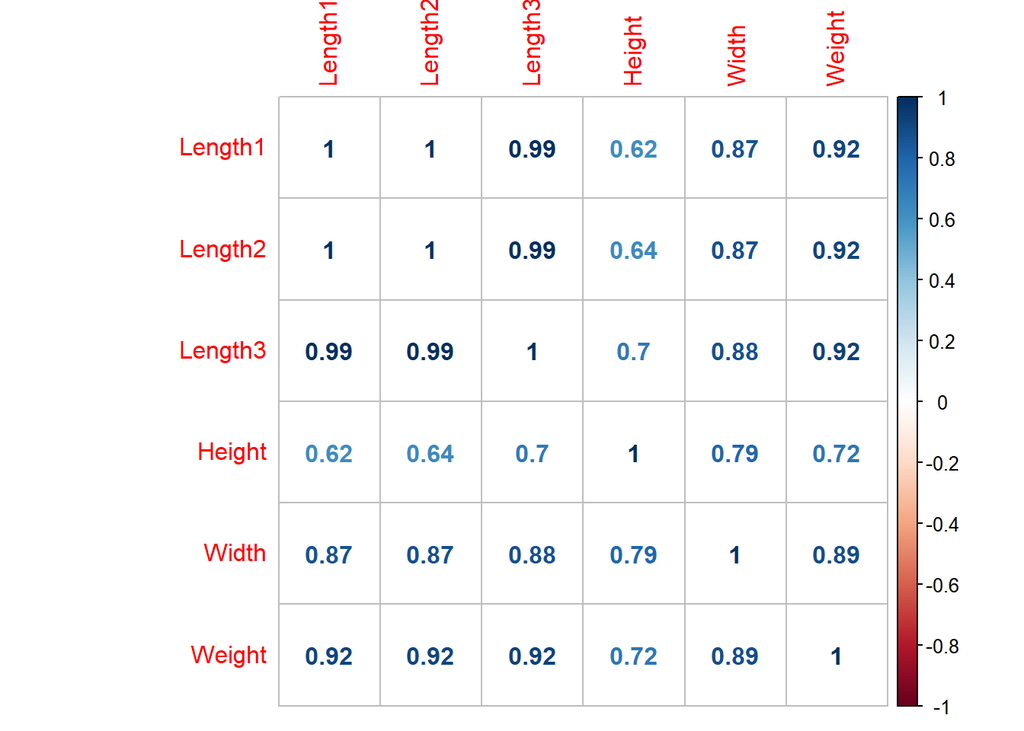

```r
correlation_fish<-cor(fish[c("Length1","Length2","Length3","Height","Width","Weight")])
library(corrplot)
corrplot(correlation_fish,method = "number")
```

As evident from the correlation matrix, Length1,Length2 and Length are highly correlated with one another This correlation between independent variables is called multicollinearity. It is advisable to use only one of those correlated independent variable in order to improve the linear regression

## REGRESSION ANALYSIS

Building the full linear with all available variables:

```r
fish_reg <- lm(Weight ~ Species + Length1 + Length2 + Length3 + Height + Width,data = fish)
summary(fish_reg)
```

```
##
## Call:
## lm(formula = Weight ~ Species + Length1 + Length2 + Length3 +
##     Height + Width, data = fish)
##
## Residuals:
##     Min      1Q  Median      3Q     Max
## -212.56  -52.52  -11.70   36.55  419.97
##
## Coefficients:
##                   Estimate Std. Error t value Pr(>|t|)
## (Intercept)      -912.7110   127.4597  -7.161 3.64e-11 ***
## SpeciesParkki     160.9212    75.9591   2.119 0.035824 *
## SpeciesPerch      133.5542   120.6083   1.107 0.269969
## SpeciesPike      -209.0262   135.4911  -1.543 0.125061
## SpeciesRoach      104.9243    91.4636   1.147 0.253188
## SpeciesSmelt      442.2125   119.6944   3.695 0.000311 ***
## SpeciesWhitefish   91.5688    96.8338   0.946 0.345901
## Length1           -79.8443    36.3322  -2.198 0.029552 *
## Length2            81.7091    45.8395   1.783 0.076746 .
## Length3            30.2726    29.4837   1.027 0.306233
## Height              5.8069    13.0931   0.444 0.658057
## Width              -0.7819    23.9477  -0.033 0.974000
## ---
## Signif. codes:  0 '***' 0.001 '**' 0.01 '*' 0.05 '.' 0.1 ' ' 1
##
## Residual standard error: 93.95 on 146 degrees of freedom
## Multiple R-squared:  0.9358, Adjusted R-squared:  0.931
## F-statistic: 193.6 on 11 and 146 DF,  p-value: < 2.2e-16
```

### OPTIMIZATION OF REGRESSION

As previously shown by the correlation matrix, “Length1”, “Length2” and “Length3” are correlated to one another, so we use only one of them “Length1” We remove “Species” entirely, as we have seen from the density graph that species wise, the density is not normally distributed.

Buidling the new regression model:-

```r
fish_reg_improved <- lm(Weight ~ Length1 + Height + Width,data = fish)
summary(fish_reg_improved)
```

```
##
## Call:
## lm(formula = Weight ~ Length1 + Height + Width, data = fish)
##
## Residuals:
##     Min      1Q  Median      3Q     Max
## -249.24  -73.13  -27.96   75.11  443.17
##
## Coefficients:
##             Estimate Std. Error t value Pr(>|t|)
## (Intercept) -511.471     28.593 -17.888  < 2e-16 ***
## Length1       22.605      2.019  11.198  < 2e-16 ***
## Height        13.590      3.848   3.532 0.000545 ***
## Width         44.266     15.321   2.889 0.004420 **
## ---
## Signif. codes:  0 '***' 0.001 '**' 0.01 '*' 0.05 '.' 0.1 ' ' 1
##
## Residual standard error: 123.6 on 154 degrees of freedom
## Multiple R-squared:  0.8828, Adjusted R-squared:  0.8805
## F-statistic: 386.7 on 3 and 154 DF,  p-value: < 2.2e-16
```

Although the R-Squared has decreased, we can see that the p-values are all close to 0.000, WHich means that all the variables we have used in the new regression model are highly significant.

### TRAINNING AND TESTING ON THE IMPROVED REGRESSION MODEL

Shuffling the data:

```r
fish_shuffled<-fish%>%sample_n(158)
#Setting the trainning and testing set
#Train set is 84.81% while Test set is the rest of the whole dataset
fish_train<-fish_shuffled[1:134,]
fish_test<-fish_shuffled[135:158,]
```

Trainning and predicting the improved model:

```r
fish_reg_improved<-lm(Weight~ Length1 + Height +Width, data = fish_train)
#Predicting the model
fish_predict<-predict(fish_reg_improved,fish_test)
```

Cross checking the observed values and predicted values

```r
head(fish_test)
```

```
##     Species Weight Length1 Length2 Length3  Height  Width
## 135   Bream    450    26.8    29.7    34.7 13.6024 4.9274
## 136   Roach    200    22.1    23.5    26.8  7.3968 4.1272
## 137   Perch    840    32.5    35.0    37.3 11.4884 7.7957
## 138   Perch     85    18.2    20.0    21.0  5.0820 2.7720
## 139   Perch   1000    39.8    43.0    45.2 11.9328 7.2772
## 140   Bream    680    31.8    35.0    40.6 15.4686 6.1306
```

```r
head(fish_predict)
```

```
##       135       136       137       138       139       140
## 493.70441 257.94560 673.28076  90.15292 845.97670 677.31191
```

Checking the performance of the model

```r
cor_reg_fish<-cor(fish_test$Weight,fish_predict)
cor_reg_fish
```

```
## [1] 0.9522394
```

Plotting and comparing our predictions with the observed values:

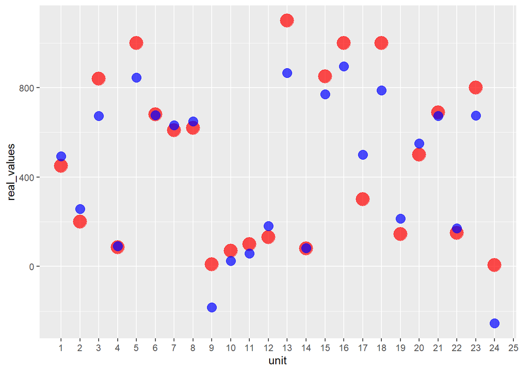

```r
pred_plot <- data.frame(pred_lin=fish_predict,real_values=fish_test$Weight,unit = seq(1,length(fish_test$Weight),by=1))

ggplot(pred_plot,aes(x=unit,y=real_values))+
  geom_point(col="red",size=6,alpha=0.7)+
  geom_point(aes(x=unit,y=pred_lin),col="blue",size=4,alpha=0.7)+
  scale_x_continuous(breaks=seq(1,25,by=1),labels  =seq(1,25,by=1),minor_breaks = NULL)
```

From the graph, we can infer that our regression is close to predicting most of the values but not yet perfect. We can further imporve our model by using a log-log model where we take the log values of our dependent and independent variables.

### FURTHER OPTIMIZATION

Trainning the new improved log model:

```r
fish_reg_log<-lm(log(Weight)~log(Length1)+log(Height)+log(Width),data=fish_train)
summary(fish_reg_log)
```

```
##
## Call:
## lm(formula = log(Weight) ~ log(Length1) + log(Height) + log(Width),
##     data = fish_train)
##
## Residuals:
##      Min       1Q   Median       3Q      Max
## -0.43347 -0.05931  0.00131  0.05586  0.27397
##
## Coefficients:
##              Estimate Std. Error t value Pr(>|t|)
## (Intercept)  -1.81221    0.12947  -14.00   <2e-16 ***
## log(Length1)  1.44873    0.05691   25.46   <2e-16 ***
## log(Height)   0.63119    0.03810   16.57   <2e-16 ***
## log(Width)    0.92973    0.07080   13.13   <2e-16 ***
## ---
## Signif. codes:  0 '***' 0.001 '**' 0.01 '*' 0.05 '.' 0.1 ' ' 1
##
## Residual standard error: 0.1018 on 130 degrees of freedom
## Multiple R-squared:  0.9941, Adjusted R-squared:  0.994
## F-statistic:  7293 on 3 and 130 DF,  p-value: < 2.2e-16
```

it is clear from the summary that the log-log multiple regression is way better than the previously imporved model. The R-Squared has improved from 0.89 to 0.99 which is great. In addition the p-values of all variables are 0.000 which means all the variables are significant.

Predicting using log-log multiple regression:

```r
fish_predict_log<-predict(fish_reg_log,fish_test)
#Reversing the log using the exponential function
fish_final_predict_log<-exp(fish_predict_log)
```

Comparing the heads of the real and predicted values:

```r
head(fish_test)
```

```
##     Species Weight Length1 Length2 Length3  Height  Width
## 135   Bream    450    26.8    29.7    34.7 13.6024 4.9274
## 136   Roach    200    22.1    23.5    26.8  7.3968 4.1272
## 137   Perch    840    32.5    35.0    37.3 11.4884 7.7957
## 138   Perch     85    18.2    20.0    21.0  5.0820 2.7720
## 139   Perch   1000    39.8    43.0    45.2 11.9328 7.2772
## 140   Bream    680    31.8    35.0    40.6 15.4686 6.1306
```

```r
head(fish_final_predict_log)
```

```
##        135        136        137        138        139        140
##  437.93697  191.22440  797.39791   78.66497 1027.48640  745.59116
```

Plotting and comparing the real values with the values predicted:

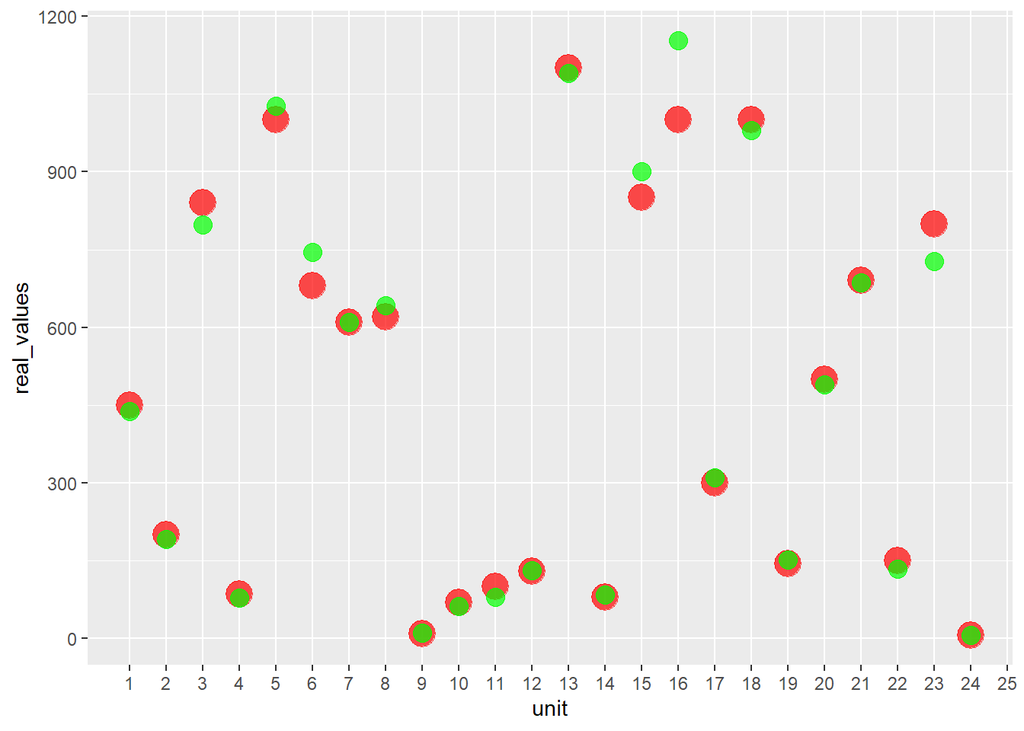

```r
pred_plot_log <- data.frame(pred_log=fish_final_predict_log,real_values=fish_test$Weight,unit = seq(1,length(fish_test$Weight),by=1))

ggplot(pred_plot_log,aes(x=unit,y=real_values))+
  geom_point(col="red",size=6,alpha=0.7)+
  geom_point(aes(x=unit,y=pred_log),col="green",size=4,alpha=0.7)+
  scale_x_continuous(breaks=seq(1,25,by=1),labels  =seq(1,25,by=1),minor_breaks = NULL)
```

As we can clearly see, the predictions are way way better than the improved model. The new log-log multiple linear regression model pretty much nails almost all of its predictions!

Summarizing the predicting power of the two regression models:

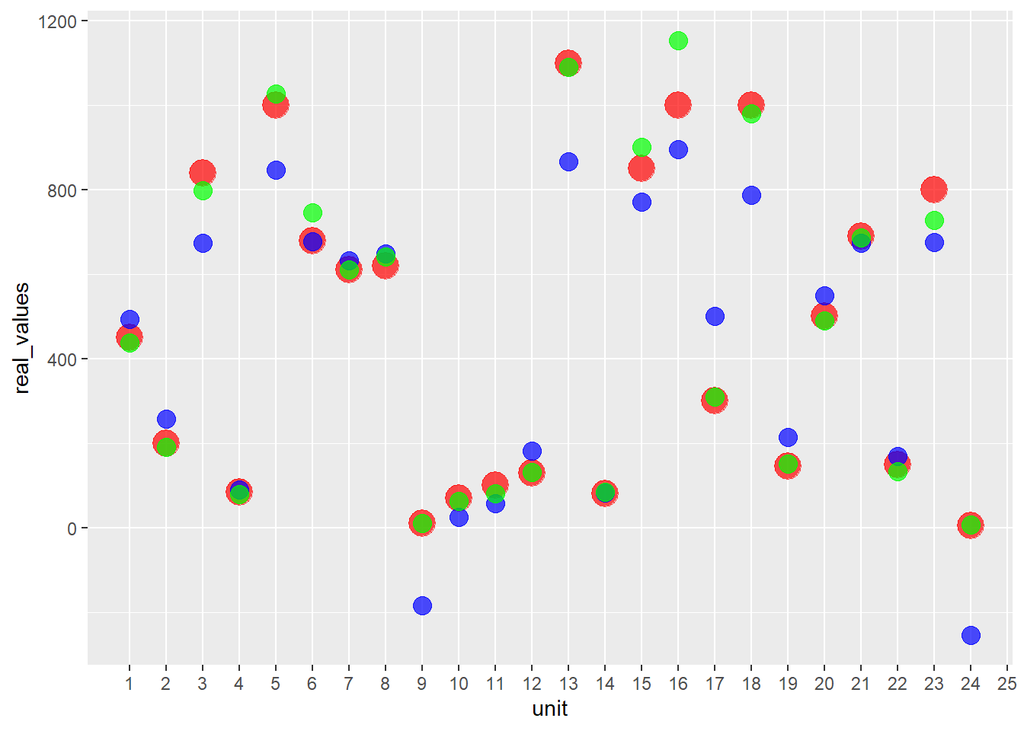

```r
pred_plot_final <- data.frame(pred_log=fish_final_predict_log,pred_lin=fish_predict,real_values=fish_test$Weight,unit = seq(1,length(fish_test$Weight),by=1))

ggplot(pred_plot_final,aes(x=unit,y=real_values))+
  geom_point(col="red",size=6,alpha=0.7)+
  geom_point(aes(x=unit,y=pred_lin),col="blue",size=4,alpha=0.7)+
  geom_point(aes(x=unit,y=pred_log),col="green",size=4,alpha=0.7)+
  scale_x_continuous(breaks=seq(1,25,by=1),labels  =seq(1,25,by=1),minor_breaks = NULL)
```

RED -> REAL VALUES, BLUE -> PREDICTED VALUES USING THE IMPROVED LINEAR REGRESSION MODEL, GREEN -> PREDICTED VALUES USING THE LOG-LOG REGRESSION MODEL.